# SBS Mutational Signatures Analysis

Ryan Corbett (adapted from C. Savonen for ALSF CCDL)

2022

**Purpose:**

Calculate and plot mutational signatures for all samples using [COSMIC signatures](https://cancer.sanger.ac.uk/cosmic) and [Alexandrov et al, 2013](https://www.ncbi.nlm.nih.gov/pubmed/23945592) mutational signatures.

#### Usage

To run this from the command line, use: `Rscript -e "rmarkdown::render('analyses/mutational-signatures/01-known_signatures.Rmd', clean = TRUE)"`

*This assumes you are in the top directory of the repository.*

## Setup

#### Packages and functions

Import necessary functions.

```r
# Magrittr pipe
`%>%` <- dplyr::`%>%`

# Import specialized functions
source(file.path("util", "mut_sig_functions.R"))

# Load this library
library(deconstructSigs)
library(tidyverse)
library("optparse")
```

## set options

```r
snv_file <- params$snv_file
output_Folder <- params$output_Folder
```

Set up directory paths.

```r
data_dir <- file.path("..", "..", "data")
input_dir <- "input"
results_dir <- file.path("results", output_Folder)
plots_dir <- file.path("plots", output_Folder)
figures_dir <- file.path("..", "..", "figures")

cosmicv2_plots <- file.path(plots_dir, "cosmicv2")
nature_plots <- file.path(plots_dir, "nature")
cosmicv3_plots <- file.path(plots_dir, "cosmicv3")

scratch_dir <- file.path("..", "..", "scratch", "mutational-signatures")
cosmicv2_scratch <- file.path(scratch_dir, output_Folder, "cosmicv2")
cosmicv3_scratch <- file.path(scratch_dir, output_Folder, "cosmicv3")
nature_scratch <- file.path(scratch_dir, output_Folder, "nature")
```

Make new directories for the results.

```r
if (!dir.exists(results_dir)) {
  dir.create(results_dir)
}
if (!dir.exists(cosmicv2_plots)) {
  dir.create(cosmicv2_plots, recursive = TRUE)
}
if (!dir.exists(nature_plots)) {
  dir.create(nature_plots, recursive = TRUE)
}
if (!dir.exists(cosmicv3_plots)) {
  dir.create(cosmicv3_plots, recursive = TRUE)
}

if (!dir.exists(scratch_dir)) {
  dir.create(scratch_dir)
}
if (!dir.exists(cosmicv2_scratch)) {
  dir.create(cosmicv2_scratch)
}
if (!dir.exists(cosmicv3_scratch)) {
  dir.create(cosmicv3_scratch)
}
if (!dir.exists(nature_scratch)) {
  dir.create(nature_scratch)
}
```

## Read in data

```r
# Declare file path for consensus file
consensus_file <- file.path(data_dir, snv_file)
```

Read in the consensus MAF file.

```r
# Read in the file
maf <- data.table::fread(consensus_file, data.table = FALSE)
```

[output not shown]

[output cut: 836 more lines]

[output not shown]

### Read in color palettes

Read in the histology colors and labels.

```r
histology_label_mapping <- readr::read_tsv(
  file.path(figures_dir, "palettes", "histology_label_color_table.tsv")
) %>%
  # Select just the columns we will need for plotting
  dplyr::select(Kids_First_Biospecimen_ID, display_group, display_order, hex_codes) %>%
  # Reorder display_group based on display_order
  dplyr::mutate(display_group = forcats::fct_reorder(display_group, display_order))
```

Set up gradient color palette for the bubble matrix plots.

```r
gradient_col_palette <- readr::read_tsv(
  file.path(figures_dir, "palettes", "gradient_color_palette.tsv")
)
# Won't need NA color this time.
gradient_col_palette <- gradient_col_palette %>%
  dplyr::filter(color_names != "na_color")
```

Read in the metadata and set it up with the color palette. Separate BS_ids into intial CNS tumors and other tumors, as mutational signatures analyses will be run on a different set of signatures for each group.

```r
metadata_df <- readr::read_tsv(file.path(data_dir, "histologies.tsv"), guess_max = 10000) %>%
#  dplyr::select("Kids_First_Biospecimen_ID", "experimental_strategy") %>%
  dplyr::inner_join(histology_label_mapping, by = "Kids_First_Biospecimen_ID") %>%
  dplyr::rename(Tumor_Sample_Barcode = "Kids_First_Biospecimen_ID")
initial_pretx_tumors <- metadata_df %>%
  filter(tumor_descriptor == "Initial CNS Tumor" & age_at_diagnosis_days < age_at_chemo_start) %>%
  pull(Tumor_Sample_Barcode)
```

Read in tmb-all file with WGS and WXS region lengths so they can be used for the Mb denominator.

```r
# Set up BED region file for TMB calculations
region_sizes <- readr::read_tsv(file.path(data_dir, "snv-mutation-tmb-all.tsv")) %>%
  dplyr::select(Tumor_Sample_Barcode, region_size)
```

## Set up data

Determine how many mutations we have per sample.

```r
mut_per_sample <- maf %>%
  dplyr::group_by(Tumor_Sample_Barcode) %>%
  dplyr::tally() %>%
  dplyr::arrange(n)

summary(mut_per_sample$n)
```

```
   Min. 1st Qu.  Median    Mean 3rd Qu.    Max.
  43499   63455   69216   67123   74846   77658
```

Graph this.

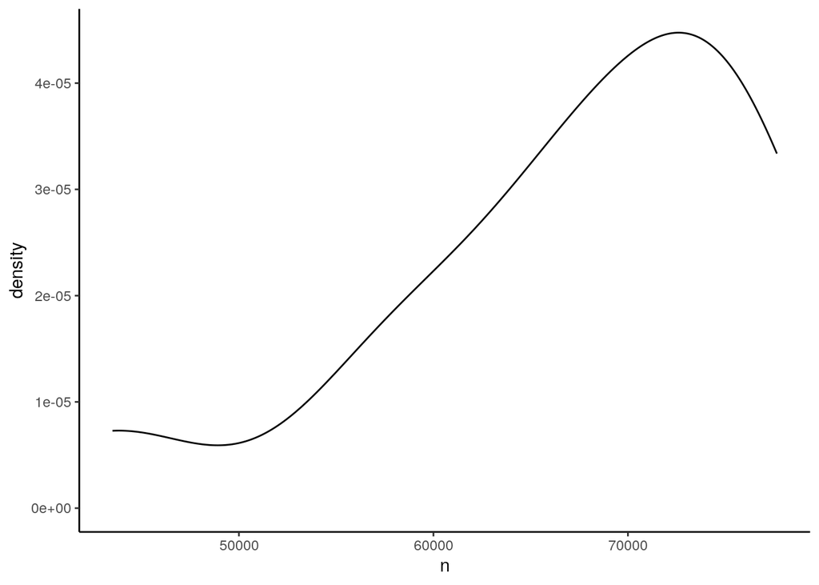

```r
ggplot2::ggplot(mut_per_sample, ggplot2::aes(x = n, geom = "density")) +
  ggplot2::geom_density() +
  ggplot2::theme_classic()
```

Make mutation data into `deconstructSigs` input format.

```r
# Convert to deconstructSigs input
sigs_input <- mut.to.sigs.input(
  mut.ref = maf,
  sample.id = "Tumor_Sample_Barcode",
  chr = "Chromosome",
  pos = "Start_Position",
  ref = "Reference_Allele",
  alt = "Allele",
  bsg = BSgenome.Hsapiens.UCSC.hg38::BSgenome.Hsapiens.UCSC.hg38
)
```

Add total mutations per sample.

```r
# Count the total number of signature mutations for each sample
total_muts <- apply(sigs_input, 1, sum)
```

## Determine Signatures for COSMIC and Alexandrov et al, 2013

Get list of tumor sample ids.

```r
tumor_sample_ids <- maf %>%
  dplyr::filter(Tumor_Sample_Barcode %in% rownames(sigs_input)) %>%
  dplyr::distinct(Tumor_Sample_Barcode) %>%
  dplyr::pull(Tumor_Sample_Barcode)
```

Get [COSMIC v2 signatures](https://cancer.sanger.ac.uk/cosmic) for each sample. This step will take some time.

```r
sample_sigs_cosmic <- lapply(tumor_sample_ids, function(sample_id) {
  # Determine the signatures contributing to the sample
  whichSignatures(
    tumor.ref = sigs_input,
    signatures.ref = signatures.cosmic,
    sample.id = sample_id,
    contexts.needed = TRUE
  )
})
# Bring along the names
names(sample_sigs_cosmic) <- tumor_sample_ids

# Create matrix of COSMIC signature weights
cosmic_weights <- lapply(sample_sigs_cosmic, "[[", "weights")
cosmic_wide <- do.call(dplyr::bind_rows, cosmic_weights) %>%
  add_column('Kids_First_Biospecimen_ID' = unlist(lapply(cosmic_weights, rownames)), .before = 1) %>%
  tibble::as_tibble() %>%
readr::write_tsv(file.path(results_dir, 'cosmicv2_signature_exposure_matrix.tsv'))
```

Get [Alexandrov et al, 2013](https://www.ncbi.nlm.nih.gov/pubmed/23945592) signatures for each sample.

```r
sample_sigs_nature <- lapply(tumor_sample_ids, function(sample_id) {
  # Determine the signatures contributing to the sample
  whichSignatures(
    tumor.ref = sigs_input,
    signatures.ref = signatures.nature2013,
    sample.id = sample_id,
    contexts.needed = TRUE
  )
})
# Bring along the names
names(sample_sigs_nature) <- tumor_sample_ids

# Create data frame of Nature signature weights
nature_weights <- lapply(sample_sigs_nature, "[[", "weights")
nature_wide <- do.call(dplyr::bind_rows, nature_weights) %>%
  add_column('Kids_First_Biospecimen_ID' = unlist(lapply(nature_weights, rownames)), .before = 1) %>%
  tibble::as_tibble() %>%
readr::write_tsv(file.path(results_dir, 'nature_signature_exposure_matrix.tsv'))
```

Get [COSMIC genome v3.3 signatures](https://cancer.sanger.ac.uk/cosmic) for each sample.

```r
signatures.cosmic.v3.3 <- read_tsv(file.path(input_dir, 'COSMIC_v3.3.1_SBS_GRCh38.txt')) %>%
  column_to_rownames('Type') %>%
  t %>%
  as.data.frame()
```

Create list of include/exclude signatures using SBSv3 mapping file. For Initial CNS tumors, therapy exposures will be excluded, but they will be retained for other tumor types.

```r
map <- read_tsv(file.path(input_dir, "sbs_v3_map.tsv"))
# Excluded signatures:
artifact_sigs <- map %>%
   filter(Broad_category == "Sequencing artifact") %>%
   pull(Signature)

environ_sigs <- map %>%
   filter(Broad_category == "Environmental exposure") %>%
   pull(Signature)

unknown <- map %>%
   filter(Broad_category == "Unknown" & Signature != "SBS39") %>%
   pull(Signature)

therapy_sigs <- map %>%
   filter(Broad_category == "Therapy exposure") %>%
   pull(Signature)

exclude_sigs <- c(artifact_sigs, environ_sigs, unknown)
include_sigs_initialPretx <- setdiff(rownames(signatures.cosmic.v3.3), c(exclude_sigs, therapy_sigs))
include_sigs_other <- setdiff(rownames(signatures.cosmic.v3.3), exclude_sigs)
```

Run signature extraction. This step will take some time.

```r
sample_sigs_cosmic_v33 <- lapply(tumor_sample_ids, function(sample_id) {
  # Determine the signatures contributing to the sample
  if (sample_id %in% initial_pretx_tumors){
    whichSignatures(
    tumor.ref = sigs_input,
    signatures.ref = signatures.cosmic.v3.3,
    sample.id = sample_id,
    contexts.needed = TRUE,
    associated = include_sigs_initialPretx
    )
  }else{
    whichSignatures(
    tumor.ref = sigs_input,
    signatures.ref = signatures.cosmic.v3.3,
    sample.id = sample_id,
    contexts.needed = TRUE,
    associated = include_sigs_other
    )
  }
})

# Bring along the names
names(sample_sigs_cosmic_v33) <- tumor_sample_ids
#
# Create matrix of COSMIC signature weights
cosmic_v33_weights <- lapply(sample_sigs_cosmic_v33, "[[", "weights")
cosmic_v33_wide <- do.call(dplyr::bind_rows, cosmic_v33_weights) %>%
  add_column('Kids_First_Biospecimen_ID' = unlist(lapply(cosmic_v33_weights, rownames)), .before = 1) %>%
  tibble::as_tibble() %>%
  readr::write_tsv(file.path(results_dir, 'cosmicv3.3_signature_exposure_matrix.tsv'))
```

### Calculate the mutations per Mb for each signature

Do this for COSMIC v2 mutation signatures.

```r
# Calculate mutations per signature
cosmic_sigs_df <- calc_mut_per_sig(
  sample_sigs_cosmic,
  muts_per_sample = total_muts,
  region_size = region_sizes,
  metadata = metadata_df
)  %>%
  dplyr::filter(grepl("Signature", signature))
```

```
Using Tumor_Sample_Barcode, Kids_First_Participant_ID, sample_id, aliquot_id, sample_type, tumor_descriptor, composition, cell_line_composition, pathology_diagnosis, pathology_free_text_diagnosis, cancer_predispositions, cohort, sub_cohort, experimental_strategy, RNA_library, match_id, cohort_partic…
```

```r
# Write this to a file but drop the color column
cosmic_sigs_df %>%
  dplyr::select(-hex_codes) %>%
  readr::write_tsv(file.path(results_dir, "cosmicv2_signatures_results.tsv"))

# Print out a preview
cosmic_sigs_df
```

| Tumor_Sample_Barcode | Kids_First_Participant_ID | sample_id | aliquot_id | sample_type | tumor_descriptor | composition | cell_line_composition | pathology_diagnosis | pathology_free_text_diagnosis | cancer_predispositions | cohort | sub_cohort | experimental_strategy | RNA_library | match_id | cohort_participant_id | primary_site | CNS_region | reported_gender | germline_sex_estimate | race | ethnicity | OS_status | EFS_event_type | extent_of_tumor_resection | clinical_status_at_event | seq_center | broad_histology | short_histology | … |
| --- | --- | --- | --- | --- | --- | --- | --- | --- | --- | --- | --- | --- | --- | --- | --- | --- | --- | --- | --- | --- | --- | --- | --- | --- | --- | --- | --- | --- | --- | --- |
| BS_M28HG0NT | PT_2WVW55DA | 7316-2092 | 711284 | Tumor | Progressive | Solid Tissue | NA | High-grade glioma/astrocytoma (WHO grade III/IV) | glioblastoma multiforme (who grade 4) | None documented | PBTA | HOPE | WGS | NA | PT_2WVW55DA_7316-2092_Solid Tissue_Progressive | C103566 | Parietal Lobe | Hemispheric | Female | Female | White | Not Hispanic or Latino | DECEASED | Progressive | Gross/Near total resection | Alive | NantOmics | Diffuse astrocytic and oligodendroglial tumor | HGAT | … |
| BS_T7WMJ08W | PT_40HTPY49 | 7316-466 | 549732 | Tumor | Initial CNS Tumor | Solid Tissue | NA | High-grade glioma/astrocytoma (WHO grade III/IV) | anaplastic astrocytoma who grade iii | None documented | PBTA | HOPE | WGS | NA | PT_40HTPY49_7316-466_Solid Tissue_Initial CNS Tumor | C99753 | Thalamus | Midline | Male | Male | Native Hawaiian or Other Pacific Islander | Hispanic or Latino | DECEASED | Progressive | Partial resection | Alive | NantOmics | Diffuse astrocytic and oligodendroglial tumor | HGAT | … |
| BS_96S0VQBN | PT_1H2REHT2 | 7316-3303 | 739781 | Tumor | Deceased | Solid Tissue | NA | High-grade glioma/astrocytoma (WHO grade III/IV) | pleomorphic xanthoastrocytoma | Neurofibromatosis, Type 1 (NF-1) | PBTA | HOPE | WGS | NA | PT_1H2REHT2_7316-3303_Solid Tissue_Deceased | C53013 | Basal Ganglia;Thalamus | Midline | Male | Male | White | Not Hispanic or Latino | DECEASED | Progressive | Not Reported | Deceased-due to disease | NantOmics | Diffuse astrocytic and oligodendroglial tumor | HGAT | … |
| BS_F064HMTP | PT_387VK1T9 | 7316-3625 | 725410 | Tumor | Initial CNS Tumor | Solid Tissue | NA | High-grade glioma/astrocytoma (WHO grade III/IV) | glioblastoma | None documented | PBTA | HOPE | WGS | NA | PT_387VK1T9_7316-3625_Solid Tissue_Initial CNS Tumor | C979572 | Parietal Lobe | Hemispheric | Female | Female | White | Not Hispanic or Latino | NA | Not Applicable | Biopsy only | Alive | NantOmics | Diffuse astrocytic and oligodendroglial tumor | HGAT | … |
| BS_M28HG0NT | PT_2WVW55DA | 7316-2092 | 711284 | Tumor | Progressive | Solid Tissue | NA | High-grade glioma/astrocytoma (WHO grade III/IV) | glioblastoma multiforme (who grade 4) | None documented | PBTA | HOPE | WGS | NA | PT_2WVW55DA_7316-2092_Solid Tissue_Progressive | C103566 | Parietal Lobe | Hemispheric | Female | Female | White | Not Hispanic or Latino | DECEASED | Progressive | Gross/Near total resection | Alive | NantOmics | Diffuse astrocytic and oligodendroglial tumor | HGAT | … |
| BS_T7WMJ08W | PT_40HTPY49 | 7316-466 | 549732 | Tumor | Initial CNS Tumor | Solid Tissue | NA | High-grade glioma/astrocytoma (WHO grade III/IV) | anaplastic astrocytoma who grade iii | None documented | PBTA | HOPE | WGS | NA | PT_40HTPY49_7316-466_Solid Tissue_Initial CNS Tumor | C99753 | Thalamus | Midline | Male | Male | Native Hawaiian or Other Pacific Islander | Hispanic or Latino | DECEASED | Progressive | Partial resection | Alive | NantOmics | Diffuse astrocytic and oligodendroglial tumor | HGAT | … |
| BS_96S0VQBN | PT_1H2REHT2 | 7316-3303 | 739781 | Tumor | Deceased | Solid Tissue | NA | High-grade glioma/astrocytoma (WHO grade III/IV) | pleomorphic xanthoastrocytoma | Neurofibromatosis, Type 1 (NF-1) | PBTA | HOPE | WGS | NA | PT_1H2REHT2_7316-3303_Solid Tissue_Deceased | C53013 | Basal Ganglia;Thalamus | Midline | Male | Male | White | Not Hispanic or Latino | DECEASED | Progressive | Not Reported | Deceased-due to disease | NantOmics | Diffuse astrocytic and oligodendroglial tumor | HGAT | … |
| BS_F064HMTP | PT_387VK1T9 | 7316-3625 | 725410 | Tumor | Initial CNS Tumor | Solid Tissue | NA | High-grade glioma/astrocytoma (WHO grade III/IV) | glioblastoma | None documented | PBTA | HOPE | WGS | NA | PT_387VK1T9_7316-3625_Solid Tissue_Initial CNS Tumor | C979572 | Parietal Lobe | Hemispheric | Female | Female | White | Not Hispanic or Latino | NA | Not Applicable | Biopsy only | Alive | NantOmics | Diffuse astrocytic and oligodendroglial tumor | HGAT | … |
| BS_M28HG0NT | PT_2WVW55DA | 7316-2092 | 711284 | Tumor | Progressive | Solid Tissue | NA | High-grade glioma/astrocytoma (WHO grade III/IV) | glioblastoma multiforme (who grade 4) | None documented | PBTA | HOPE | WGS | NA | PT_2WVW55DA_7316-2092_Solid Tissue_Progressive | C103566 | Parietal Lobe | Hemispheric | Female | Female | White | Not Hispanic or Latino | DECEASED | Progressive | Gross/Near total resection | Alive | NantOmics | Diffuse astrocytic and oligodendroglial tumor | HGAT | … |
| BS_T7WMJ08W | PT_40HTPY49 | 7316-466 | 549732 | Tumor | Initial CNS Tumor | Solid Tissue | NA | High-grade glioma/astrocytoma (WHO grade III/IV) | anaplastic astrocytoma who grade iii | None documented | PBTA | HOPE | WGS | NA | PT_40HTPY49_7316-466_Solid Tissue_Initial CNS Tumor | C99753 | Thalamus | Midline | Male | Male | Native Hawaiian or Other Pacific Islander | Hispanic or Latino | DECEASED | Progressive | Partial resection | Alive | NantOmics | Diffuse astrocytic and oligodendroglial tumor | HGAT | … |

[output cut: 110 more lines]

Do this for COSMIC v3.3 mutation signatures.

```r
# Calculate mutations per signature
cosmicv3_sigs_df <- calc_mut_per_sig(
  sample_sigs_cosmic_v33,
  muts_per_sample = total_muts,
  region_size = region_sizes,
  metadata = metadata_df
) %>%
  dplyr::filter(grepl("SBS", signature))
```

```
Using Tumor_Sample_Barcode, Kids_First_Participant_ID, sample_id, aliquot_id, sample_type, tumor_descriptor, composition, cell_line_composition, pathology_diagnosis, pathology_free_text_diagnosis, cancer_predispositions, cohort, sub_cohort, experimental_strategy, RNA_library, match_id, cohort_partic…
```

```r
# Write this to a file but drop the color column
cosmicv3_sigs_df %>%
#  dplyr::filter(grepl("SBS", signature)) %>%
  dplyr::select(-hex_codes) %>%
  readr::write_tsv(file.path(results_dir, "cosmicv3.3_signatures_results.tsv"))

# Print out a preview
cosmicv3_sigs_df
```

| Tumor_Sample_Barcode | Kids_First_Participant_ID | sample_id | aliquot_id | sample_type | tumor_descriptor | composition | cell_line_composition | pathology_diagnosis | pathology_free_text_diagnosis | cancer_predispositions | cohort | sub_cohort | experimental_strategy | RNA_library | match_id | cohort_participant_id | primary_site | CNS_region | reported_gender | germline_sex_estimate | race | ethnicity | OS_status | EFS_event_type | extent_of_tumor_resection | clinical_status_at_event | seq_center | broad_histology | short_histology | … |
| --- | --- | --- | --- | --- | --- | --- | --- | --- | --- | --- | --- | --- | --- | --- | --- | --- | --- | --- | --- | --- | --- | --- | --- | --- | --- | --- | --- | --- | --- | --- |
| BS_M28HG0NT | PT_2WVW55DA | 7316-2092 | 711284 | Tumor | Progressive | Solid Tissue | NA | High-grade glioma/astrocytoma (WHO grade III/IV) | glioblastoma multiforme (who grade 4) | None documented | PBTA | HOPE | WGS | NA | PT_2WVW55DA_7316-2092_Solid Tissue_Progressive | C103566 | Parietal Lobe | Hemispheric | Female | Female | White | Not Hispanic or Latino | DECEASED | Progressive | Gross/Near total resection | Alive | NantOmics | Diffuse astrocytic and oligodendroglial tumor | HGAT | … |
| BS_T7WMJ08W | PT_40HTPY49 | 7316-466 | 549732 | Tumor | Initial CNS Tumor | Solid Tissue | NA | High-grade glioma/astrocytoma (WHO grade III/IV) | anaplastic astrocytoma who grade iii | None documented | PBTA | HOPE | WGS | NA | PT_40HTPY49_7316-466_Solid Tissue_Initial CNS Tumor | C99753 | Thalamus | Midline | Male | Male | Native Hawaiian or Other Pacific Islander | Hispanic or Latino | DECEASED | Progressive | Partial resection | Alive | NantOmics | Diffuse astrocytic and oligodendroglial tumor | HGAT | … |
| BS_96S0VQBN | PT_1H2REHT2 | 7316-3303 | 739781 | Tumor | Deceased | Solid Tissue | NA | High-grade glioma/astrocytoma (WHO grade III/IV) | pleomorphic xanthoastrocytoma | Neurofibromatosis, Type 1 (NF-1) | PBTA | HOPE | WGS | NA | PT_1H2REHT2_7316-3303_Solid Tissue_Deceased | C53013 | Basal Ganglia;Thalamus | Midline | Male | Male | White | Not Hispanic or Latino | DECEASED | Progressive | Not Reported | Deceased-due to disease | NantOmics | Diffuse astrocytic and oligodendroglial tumor | HGAT | … |
| BS_F064HMTP | PT_387VK1T9 | 7316-3625 | 725410 | Tumor | Initial CNS Tumor | Solid Tissue | NA | High-grade glioma/astrocytoma (WHO grade III/IV) | glioblastoma | None documented | PBTA | HOPE | WGS | NA | PT_387VK1T9_7316-3625_Solid Tissue_Initial CNS Tumor | C979572 | Parietal Lobe | Hemispheric | Female | Female | White | Not Hispanic or Latino | NA | Not Applicable | Biopsy only | Alive | NantOmics | Diffuse astrocytic and oligodendroglial tumor | HGAT | … |
| BS_M28HG0NT | PT_2WVW55DA | 7316-2092 | 711284 | Tumor | Progressive | Solid Tissue | NA | High-grade glioma/astrocytoma (WHO grade III/IV) | glioblastoma multiforme (who grade 4) | None documented | PBTA | HOPE | WGS | NA | PT_2WVW55DA_7316-2092_Solid Tissue_Progressive | C103566 | Parietal Lobe | Hemispheric | Female | Female | White | Not Hispanic or Latino | DECEASED | Progressive | Gross/Near total resection | Alive | NantOmics | Diffuse astrocytic and oligodendroglial tumor | HGAT | … |
| BS_T7WMJ08W | PT_40HTPY49 | 7316-466 | 549732 | Tumor | Initial CNS Tumor | Solid Tissue | NA | High-grade glioma/astrocytoma (WHO grade III/IV) | anaplastic astrocytoma who grade iii | None documented | PBTA | HOPE | WGS | NA | PT_40HTPY49_7316-466_Solid Tissue_Initial CNS Tumor | C99753 | Thalamus | Midline | Male | Male | Native Hawaiian or Other Pacific Islander | Hispanic or Latino | DECEASED | Progressive | Partial resection | Alive | NantOmics | Diffuse astrocytic and oligodendroglial tumor | HGAT | … |
| BS_96S0VQBN | PT_1H2REHT2 | 7316-3303 | 739781 | Tumor | Deceased | Solid Tissue | NA | High-grade glioma/astrocytoma (WHO grade III/IV) | pleomorphic xanthoastrocytoma | Neurofibromatosis, Type 1 (NF-1) | PBTA | HOPE | WGS | NA | PT_1H2REHT2_7316-3303_Solid Tissue_Deceased | C53013 | Basal Ganglia;Thalamus | Midline | Male | Male | White | Not Hispanic or Latino | DECEASED | Progressive | Not Reported | Deceased-due to disease | NantOmics | Diffuse astrocytic and oligodendroglial tumor | HGAT | … |
| BS_F064HMTP | PT_387VK1T9 | 7316-3625 | 725410 | Tumor | Initial CNS Tumor | Solid Tissue | NA | High-grade glioma/astrocytoma (WHO grade III/IV) | glioblastoma | None documented | PBTA | HOPE | WGS | NA | PT_387VK1T9_7316-3625_Solid Tissue_Initial CNS Tumor | C979572 | Parietal Lobe | Hemispheric | Female | Female | White | Not Hispanic or Latino | NA | Not Applicable | Biopsy only | Alive | NantOmics | Diffuse astrocytic and oligodendroglial tumor | HGAT | … |
| BS_M28HG0NT | PT_2WVW55DA | 7316-2092 | 711284 | Tumor | Progressive | Solid Tissue | NA | High-grade glioma/astrocytoma (WHO grade III/IV) | glioblastoma multiforme (who grade 4) | None documented | PBTA | HOPE | WGS | NA | PT_2WVW55DA_7316-2092_Solid Tissue_Progressive | C103566 | Parietal Lobe | Hemispheric | Female | Female | White | Not Hispanic or Latino | DECEASED | Progressive | Gross/Near total resection | Alive | NantOmics | Diffuse astrocytic and oligodendroglial tumor | HGAT | … |
| BS_T7WMJ08W | PT_40HTPY49 | 7316-466 | 549732 | Tumor | Initial CNS Tumor | Solid Tissue | NA | High-grade glioma/astrocytoma (WHO grade III/IV) | anaplastic astrocytoma who grade iii | None documented | PBTA | HOPE | WGS | NA | PT_40HTPY49_7316-466_Solid Tissue_Initial CNS Tumor | C99753 | Thalamus | Midline | Male | Male | Native Hawaiian or Other Pacific Islander | Hispanic or Latino | DECEASED | Progressive | Partial resection | Alive | NantOmics | Diffuse astrocytic and oligodendroglial tumor | HGAT | … |

[output cut: 306 more lines]

Do this for Alexandrov et al, 2013 mutation signatures.

```r
#Calculate mutations per signature
nature_sigs_df <- calc_mut_per_sig(
  sample_sigs_nature,
  muts_per_sample = total_muts,
  region_size = region_sizes,
  metadata = metadata_df
)  %>%
  dplyr::filter(grepl("Signature", signature))
```

```
Using Tumor_Sample_Barcode, Kids_First_Participant_ID, sample_id, aliquot_id, sample_type, tumor_descriptor, composition, cell_line_composition, pathology_diagnosis, pathology_free_text_diagnosis, cancer_predispositions, cohort, sub_cohort, experimental_strategy, RNA_library, match_id, cohort_partic…
```

```r
# Write this to a file but drop the color column
nature_sigs_df %>%
#  dplyr::filter(grepl("SBS", signature)) %>%
  dplyr::select(-hex_codes) %>%
  readr::write_tsv(file.path(results_dir, "nature_signatures_results.tsv"))

# Print out a preview
nature_sigs_df
```

| Tumor_Sample_Barcode | Kids_First_Participant_ID | sample_id | aliquot_id | sample_type | tumor_descriptor | composition | cell_line_composition | pathology_diagnosis | pathology_free_text_diagnosis | cancer_predispositions | cohort | sub_cohort | experimental_strategy | RNA_library | match_id | cohort_participant_id | primary_site | CNS_region | reported_gender | germline_sex_estimate | race | ethnicity | OS_status | EFS_event_type | extent_of_tumor_resection | clinical_status_at_event | seq_center | broad_histology | short_histology | … |
| --- | --- | --- | --- | --- | --- | --- | --- | --- | --- | --- | --- | --- | --- | --- | --- | --- | --- | --- | --- | --- | --- | --- | --- | --- | --- | --- | --- | --- | --- | --- |
| BS_M28HG0NT | PT_2WVW55DA | 7316-2092 | 711284 | Tumor | Progressive | Solid Tissue | NA | High-grade glioma/astrocytoma (WHO grade III/IV) | glioblastoma multiforme (who grade 4) | None documented | PBTA | HOPE | WGS | NA | PT_2WVW55DA_7316-2092_Solid Tissue_Progressive | C103566 | Parietal Lobe | Hemispheric | Female | Female | White | Not Hispanic or Latino | DECEASED | Progressive | Gross/Near total resection | Alive | NantOmics | Diffuse astrocytic and oligodendroglial tumor | HGAT | … |
| BS_T7WMJ08W | PT_40HTPY49 | 7316-466 | 549732 | Tumor | Initial CNS Tumor | Solid Tissue | NA | High-grade glioma/astrocytoma (WHO grade III/IV) | anaplastic astrocytoma who grade iii | None documented | PBTA | HOPE | WGS | NA | PT_40HTPY49_7316-466_Solid Tissue_Initial CNS Tumor | C99753 | Thalamus | Midline | Male | Male | Native Hawaiian or Other Pacific Islander | Hispanic or Latino | DECEASED | Progressive | Partial resection | Alive | NantOmics | Diffuse astrocytic and oligodendroglial tumor | HGAT | … |
| BS_96S0VQBN | PT_1H2REHT2 | 7316-3303 | 739781 | Tumor | Deceased | Solid Tissue | NA | High-grade glioma/astrocytoma (WHO grade III/IV) | pleomorphic xanthoastrocytoma | Neurofibromatosis, Type 1 (NF-1) | PBTA | HOPE | WGS | NA | PT_1H2REHT2_7316-3303_Solid Tissue_Deceased | C53013 | Basal Ganglia;Thalamus | Midline | Male | Male | White | Not Hispanic or Latino | DECEASED | Progressive | Not Reported | Deceased-due to disease | NantOmics | Diffuse astrocytic and oligodendroglial tumor | HGAT | … |
| BS_F064HMTP | PT_387VK1T9 | 7316-3625 | 725410 | Tumor | Initial CNS Tumor | Solid Tissue | NA | High-grade glioma/astrocytoma (WHO grade III/IV) | glioblastoma | None documented | PBTA | HOPE | WGS | NA | PT_387VK1T9_7316-3625_Solid Tissue_Initial CNS Tumor | C979572 | Parietal Lobe | Hemispheric | Female | Female | White | Not Hispanic or Latino | NA | Not Applicable | Biopsy only | Alive | NantOmics | Diffuse astrocytic and oligodendroglial tumor | HGAT | … |
| BS_M28HG0NT | PT_2WVW55DA | 7316-2092 | 711284 | Tumor | Progressive | Solid Tissue | NA | High-grade glioma/astrocytoma (WHO grade III/IV) | glioblastoma multiforme (who grade 4) | None documented | PBTA | HOPE | WGS | NA | PT_2WVW55DA_7316-2092_Solid Tissue_Progressive | C103566 | Parietal Lobe | Hemispheric | Female | Female | White | Not Hispanic or Latino | DECEASED | Progressive | Gross/Near total resection | Alive | NantOmics | Diffuse astrocytic and oligodendroglial tumor | HGAT | … |
| BS_T7WMJ08W | PT_40HTPY49 | 7316-466 | 549732 | Tumor | Initial CNS Tumor | Solid Tissue | NA | High-grade glioma/astrocytoma (WHO grade III/IV) | anaplastic astrocytoma who grade iii | None documented | PBTA | HOPE | WGS | NA | PT_40HTPY49_7316-466_Solid Tissue_Initial CNS Tumor | C99753 | Thalamus | Midline | Male | Male | Native Hawaiian or Other Pacific Islander | Hispanic or Latino | DECEASED | Progressive | Partial resection | Alive | NantOmics | Diffuse astrocytic and oligodendroglial tumor | HGAT | … |
| BS_96S0VQBN | PT_1H2REHT2 | 7316-3303 | 739781 | Tumor | Deceased | Solid Tissue | NA | High-grade glioma/astrocytoma (WHO grade III/IV) | pleomorphic xanthoastrocytoma | Neurofibromatosis, Type 1 (NF-1) | PBTA | HOPE | WGS | NA | PT_1H2REHT2_7316-3303_Solid Tissue_Deceased | C53013 | Basal Ganglia;Thalamus | Midline | Male | Male | White | Not Hispanic or Latino | DECEASED | Progressive | Not Reported | Deceased-due to disease | NantOmics | Diffuse astrocytic and oligodendroglial tumor | HGAT | … |
| BS_F064HMTP | PT_387VK1T9 | 7316-3625 | 725410 | Tumor | Initial CNS Tumor | Solid Tissue | NA | High-grade glioma/astrocytoma (WHO grade III/IV) | glioblastoma | None documented | PBTA | HOPE | WGS | NA | PT_387VK1T9_7316-3625_Solid Tissue_Initial CNS Tumor | C979572 | Parietal Lobe | Hemispheric | Female | Female | White | Not Hispanic or Latino | NA | Not Applicable | Biopsy only | Alive | NantOmics | Diffuse astrocytic and oligodendroglial tumor | HGAT | … |
| BS_M28HG0NT | PT_2WVW55DA | 7316-2092 | 711284 | Tumor | Progressive | Solid Tissue | NA | High-grade glioma/astrocytoma (WHO grade III/IV) | glioblastoma multiforme (who grade 4) | None documented | PBTA | HOPE | WGS | NA | PT_2WVW55DA_7316-2092_Solid Tissue_Progressive | C103566 | Parietal Lobe | Hemispheric | Female | Female | White | Not Hispanic or Latino | DECEASED | Progressive | Gross/Near total resection | Alive | NantOmics | Diffuse astrocytic and oligodendroglial tumor | HGAT | … |
| BS_T7WMJ08W | PT_40HTPY49 | 7316-466 | 549732 | Tumor | Initial CNS Tumor | Solid Tissue | NA | High-grade glioma/astrocytoma (WHO grade III/IV) | anaplastic astrocytoma who grade iii | None documented | PBTA | HOPE | WGS | NA | PT_40HTPY49_7316-466_Solid Tissue_Initial CNS Tumor | C99753 | Thalamus | Midline | Male | Male | Native Hawaiian or Other Pacific Islander | Hispanic or Latino | DECEASED | Progressive | Partial resection | Alive | NantOmics | Diffuse astrocytic and oligodendroglial tumor | HGAT | … |

[output cut: 98 more lines]

## Mutation signature bubble matrix by histology groups

For COSMIC v2 signatures

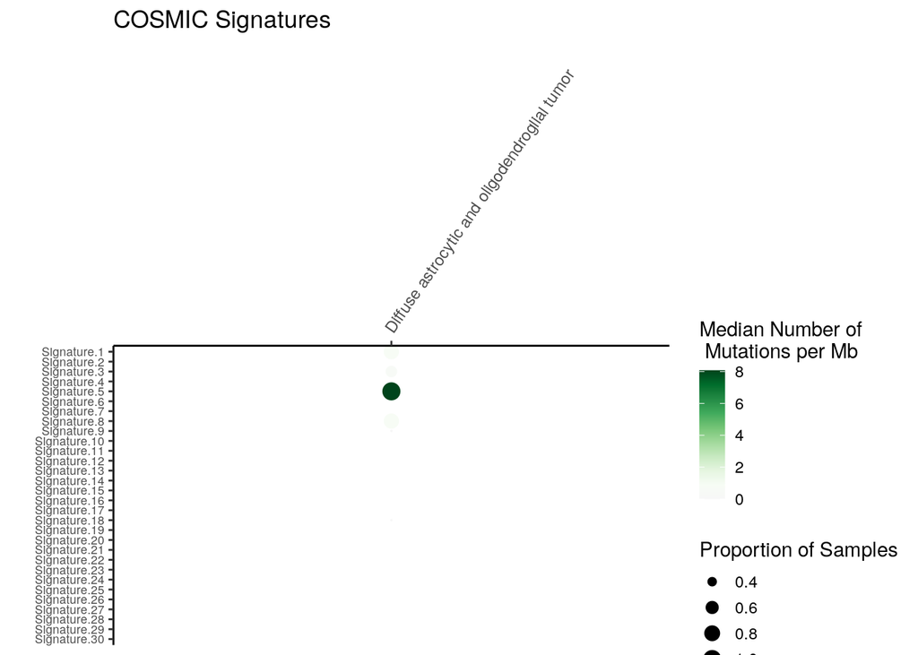

```r
bubble_matrix_plot(cosmic_sigs_df,
                   label = "COSMIC Signatures",
                   color_palette = gradient_col_palette$hex_codes
)
```

```r
ggplot2::ggsave(
  file.path(cosmicv2_plots, "bubble_matrix_cosmicv2_mutation_sig.png"),
  width = 30, height = 20, units = "cm")
```

For Nature signatures

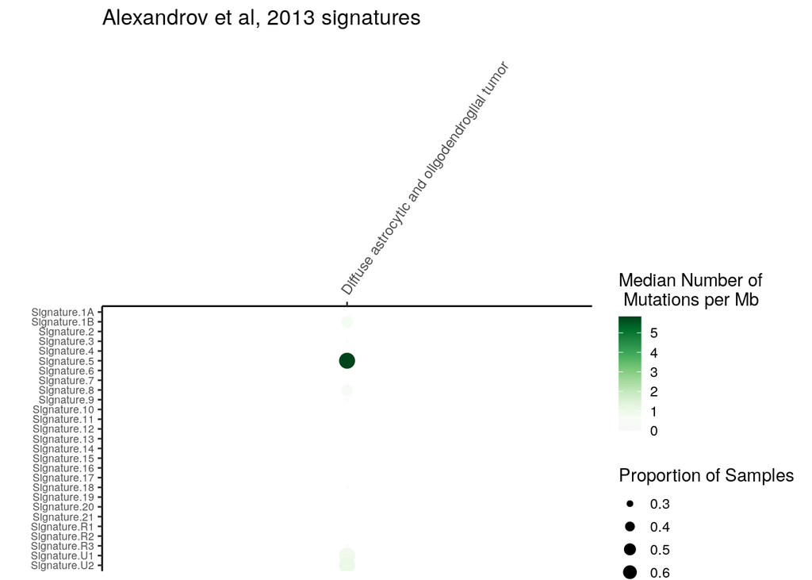

```r
bubble_matrix_plot(nature_sigs_df,
                   label = "Alexandrov et al, 2013 signatures",
                   color_palette = gradient_col_palette$hex_codes)
```

```r
ggplot2::ggsave(
  file.path(nature_plots, "bubble_matrix_nature_mutation_sig.png"),
  width = 30, height = 20, units = "cm")
```

For COSMIC v3.3 signatures

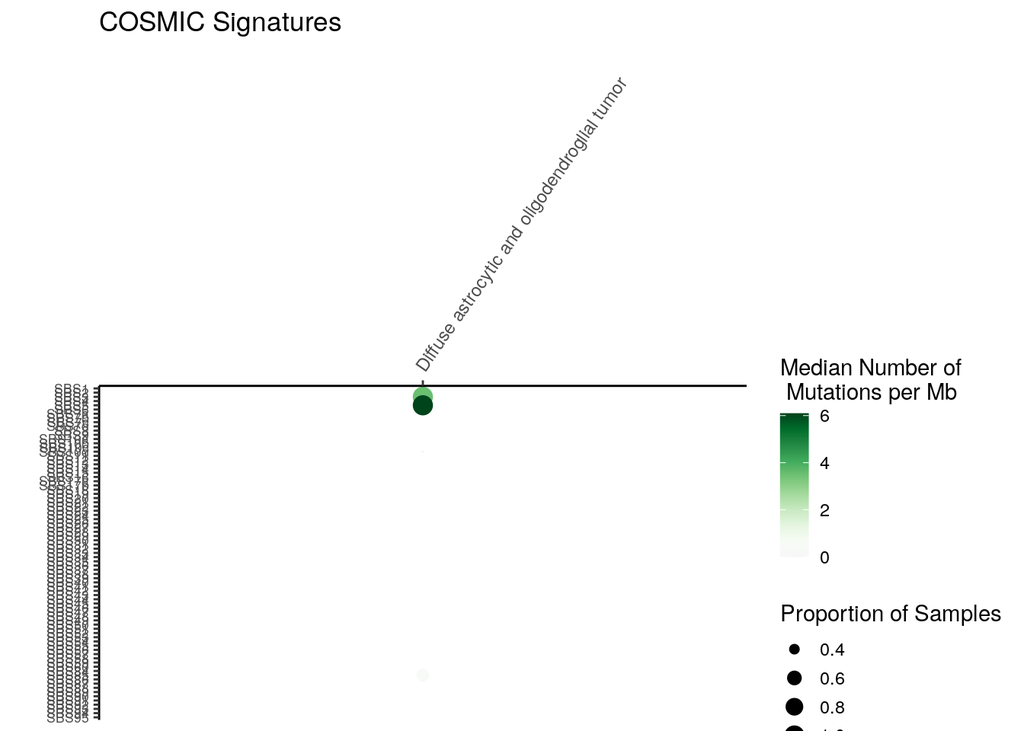

```r
bubble_matrix_plot(cosmicv3_sigs_df,
                   label = "COSMIC Signatures",
                   color_palette = gradient_col_palette$hex_codes
)
```

```r
ggplot2::ggsave(
  file.path(cosmicv3_plots, "bubble_matrix_cosmicv3_mutation_sig.png"),
  width = 30, height = 20, units = "cm")
```

## Mutation signature grouped bar plots for each histology group

```r
# Make grouped bar plots
lapply(unique(cosmic_sigs_df$display_group),
  grouped_sig_barplot,
  sig_num_df = cosmic_sigs_df,
  output_dir = file.path(cosmicv2_scratch, "signature_grouped_barplots"),
  label = "cosmic_v2"
)
```

Make these plots for Alexandrov et al, 2013 signatures.

```r
# Make grouped bar plots
lapply(unique(nature_sigs_df$display_group),
  grouped_sig_barplot,
  sig_num_df = nature_sigs_df,
  output_dir = file.path(nature_scratch, "signature_grouped_barplots"),
  label = "nature"
)
```

Make these plots for COSMIC v3.3 signatures.

```r
# Make grouped bar plots
lapply(unique(cosmicv3_sigs_df$display_group),
  grouped_sig_barplot,
  sig_num_df = cosmicv3_sigs_df,
  output_dir = file.path(cosmicv3_scratch, "signature_grouped_barplots"),
  label = "cosmic_v3.3"
)
```